# Geospatial Analysis with R

Class 9

Lyndon Estes & Zhiwen Zhu

9/27/2017

# Today

- Housekeeping
  - Extra labs (Thursday at 10.30; Friday at 2.30 pm)
  - Assignment 3
- Review practical from last class
- Some more `lapply`/`sapply` practice
- Plotting

# Practical assignment

1. Use `lapply` and `sapply` to calculate the `colSums` (columns “pl”, “ra”, “mm”) for observations where “uuid” contains the values “8424”, “166f”, “99f9”. This means you will have to use the grep approach to subsetting, rather than `farmers[farmers$date == x, c("pl", "ra", "mm")]`
2. Use `write.csv` to write out the outputs of the `sapply` version of this, where you have the results for “pl”, “ra”, “mm” as columns, and the partial strings as rows. That means you apply `t` to the resulting object that you direct `sapply` to. I haven’t shown you `write.csv` yet, so try and figure this out by adapting examples from the help file for this function (`?write.csv`)
3. Calculate the sum of “ra” for each date in `farmers`. Plot the results against date.

# Answers - `lapply`/`sapply` and `colSums`

Two possible interpretations, starting with this, the column sums for all farmers whose IDs match those values.

```r
# reload data
farmers <- read.csv("~/Desktop/farmer_test.csv", stringsAsFactors = FALSE)
farmers$date <- as.Date(farmers$date)
farmers <- farmers[order(farmers$date), ]  # reorder farmers by date
dates <- unique(farmers$date)  # unique dates

# grep
colSums(farmers[grep("8424|166f|99f9", farmers$uuid), c("pl", "ra", "mm")])
```

```
## pl ra mm
##  5  2 69
```

The second interpretation is this, the column sums for the farmer matches to each of those ids

```r
farmer_out <- t(sapply(c("8424", "166f", "99f9"), function(x) {
  dat <- farmers[grep(x, farmers$uuid), c("pl", "ra", "mm")]
  colSums(dat)
}))
```

Pay most attention to the way in which multiple matches are combined into a single `grep` (interpretation 1), where the “|” (pipe) character is used to mean “or”. Another way we can use the pipe operator

```r
farmers[farmers$uuid == "009a8424" | farmers$uuid == "019d99f9", ]
```

```
##        uuid       date pl ra mm
## 1  009a8424 2016-10-31  1  0  5
## 9  019d99f9 2016-10-31  0  0  2
## 10 019d99f9 2016-11-07  0  0  7
## 11 019d99f9 2016-11-14  1  0 10
## 2  009a8424 2016-11-21  1  0  9
## 12 019d99f9 2016-11-21  1  1  8
```

The literal translation of the above is:

“find all observations in `farmers` where uuid exactly matches ‘009a8424’ or where uuid exactly matches ‘019d99f9’”

# Answers - write.csv

Easiest - check it out

```r
write.csv(farmer_out, file = "~/Desktop/farmer_out.csv")
```

If you don’t want rownames at all

```r
write.csv(farmer_out, file = "~/Desktop/farmer_out.csv", row.names = FALSE)
```

Let’s say you want to keep what’s already in that csv, and just add to it

```r
write.csv(farmer_out, file = "~/Desktop/farmer_out.csv")  # create the 1st again
write.table(farmer_out, file = "~/Desktop/farmer_out.csv", append = TRUE,
            sep = ",", col.names = FALSE)  # use write.table to append to it
```

But do we have to save it as a csv? Certainly not. We can save it as an R data file (.rda, .Rdata)

```r
save(farmer_out, file = "~/Desktop/farmer_out.rda")  # common
rm(list = ls())
load("~/Desktop/farmer_out.rda")
farmer_out
save(farmer_out, file = "~/Desktop/farmer_out.Rdata")
rm(list = ls())
load("~/Desktop/farmer_out.Rdata")  # common
farmer_out
save(farmer_out, file = "~/Desktop/farmer_out.rd")
rm(list = ls())
load("~/Desktop/farmer_out.rd")  # not advisable
farmer_out
```

The above isn’t displayed, but if you run it (changing output file paths to suit your system) you will see they are all the same.

Note even the .rd extension works. But please don’t use it. I prefer .rda.

# An extra bit on lapply/sapply

Thanks to Nara, we were shown an excellent interactive package for learning R

```r
install.packages("swirl")
library(swirl)
```

Work through instructions to get to exercise 10–do it in next 10 minutes

Key points made in tutorial:

1. `lapply`/`sapply` are primarily used for split-apply-combine operations.
2. *apply used:
   - most simply with pre-existing functions (and uncomplicated subsets)
     - e.g. `apply(somedata, 2, sum)`; `sapply(data, sum)`
   - or with anonymous functions (for operations not defined by existing function, e.g. a custom or complicated subsetting/splitting operation)
     - e.g. our operations by date or by uuid on `farmers`
3. Not stated, but the reason that `for` not typically used:
   - harder to do the combine step
   - more work to *apply* a function, even pre-defined ones

     ```r
     out <- rep(NULL, 3)
     for(i in colnames(farmers)[3:5]) {
       out[i] <- sum(farmers[, i])
     }
     out
     ```

     ```
     ##   pl   ra   mm
     ##  870  510 8781
     ```

     Versus

     ```r
     out <- sapply(farmers[, 3:5], sum)
     out
     ```

     ```
     ##   pl   ra   mm
     ##  870  510 8781
     ```

# Answers - plotting

Simplest plot

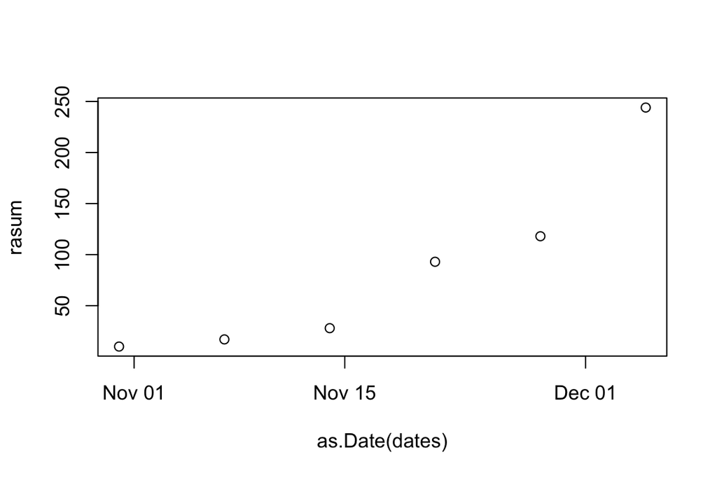

```r
rasum <- sapply(dates, function(x) {
  sum(farmers[farmers$date == x, "ra"])
})

plot(as.Date(dates), rasum)
```

Fancier

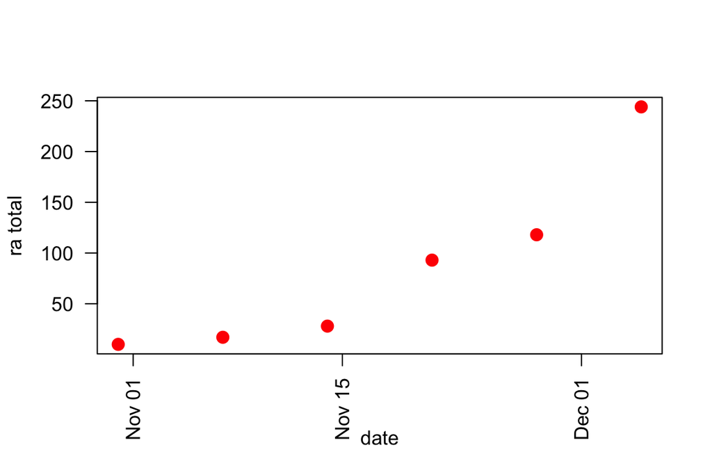

```r
plot(as.Date(dates), rasum, xlab = "date", ylab = "ra total",
     pch = 20, col = "red", cex = 2, # up to here was exercise given
     las = 2)  # an extra step--rotate axis values
```

# More plotting

First create some data.

```r
farmers2 <- t(sapply(dates, function(x) {
  dat <- farmers[farmers$date == x, c("pl", "ra", "mm")]
  colSums(dat)
}))
farmers2 <- cbind.data.frame("date" = as.Date(dates), farmers2)
rownames(farmers2) <- 1:nrow(farmers2)  # rownames were dates, want them just #
```

Now, three plots, one for column “pl”, “ra”, “mm” as y, date as x. Starting without a for loop

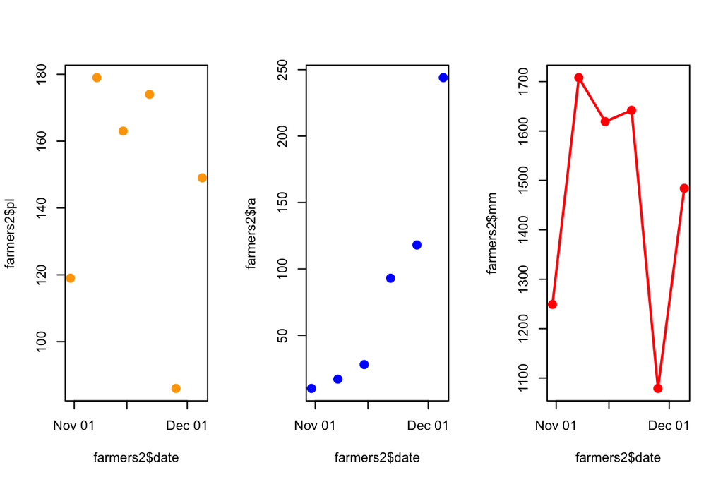

```r
# par defines initial plot parameters, here a figure with 1 row and 3 columns
par(mfrow = c(1, 3))
plot(farmers2$date, farmers2$pl, pch = 20, col = "orange", cex = 2)
plot(farmers2$date, farmers2$ra, pch = 20, col = "blue", cex = 2)
plot(farmers2$date, farmers2$mm, pch = 20, col = "red", cex = 2)
lines(farmers2$date, farmers2$mm, col = "red", lwd = 2)
```

# More plotting 2

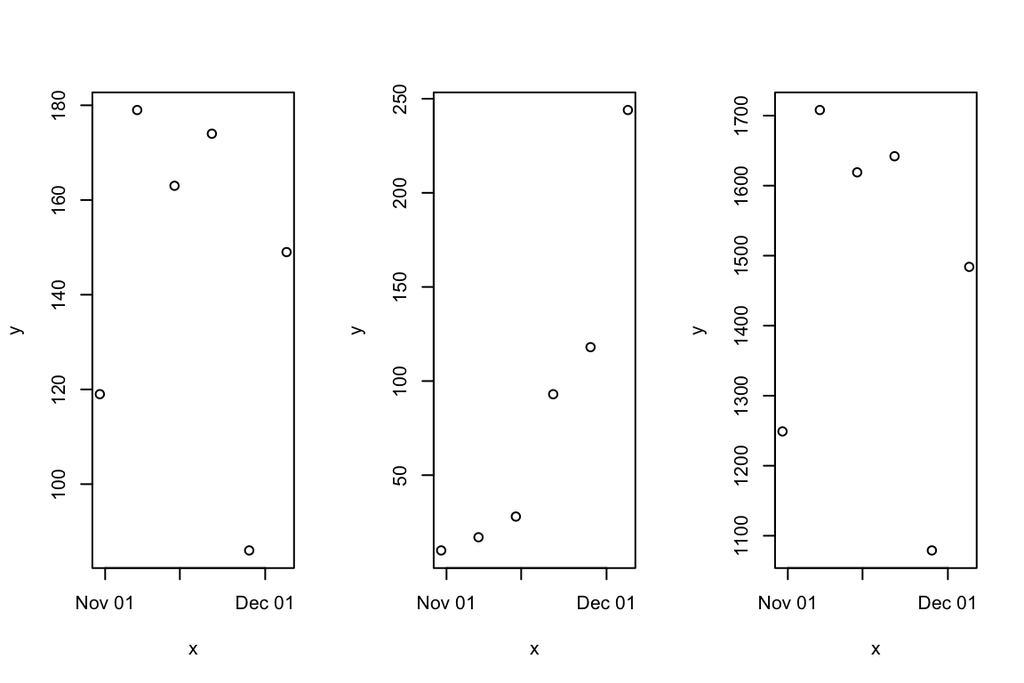

```r
par(mfrow = c(1, 3))
for(i in c("pl", "ra", "mm")) {
  x <- farmers2$date
  y <- farmers2[, i]
  plot(x, y)
}
```